# Long-term cost-effectiveness of subcutaneous versus transvenous implantable cardioverter-defibrillators across sudden cardiac death risk algorithms in hypertrophic cardiomyopathy

Nathan Green, UCL

Yang Chen, UCL

2026-10-22

# Introduction

Hypertrophic cardiomyopathy (HCM) is a common inherited heart muscle disorder and a leading cause of sudden cardiac death (SCD) in young adults. Patients at high risk of SCD need to be identified so they can be offered lifesaving prophylactic treatment with an implantable cardioverter-defibrillator (ICD). Contemporary guidelines recommend that sudden death risk is assessed using quantitative clinical risk prediction models (O’Mahony et al. 2014; Ommen et al. 2020), yet real-world ICD implantation rates vary substantially across international healthcare systems (Nauffal et al. 2021).

In our previous cost-effectiveness analysis (Green et al. 2024), we evaluated the European Society of Cardiology (ESC) 5-year HCM Risk-SCD prediction algorithm (O’Mahony et al. 2014) for primary prevention transvenous ICD (TV-ICD) implantation over a 12-year time horizon without device replacement. However, HCM patients are typically implanted at a young mean age (~48 years) and face decades of living with a device, requiring multiple generator replacements over their lifetime. Furthermore, the clinical landscape has shifted with the widespread adoption of the subcutaneous ICD (S-ICD) (Lambiase et al. 2022; Knops et al. 2020). By placing the electrode and generator entirely extrathoracically, the S-ICD eliminates intravascular lead placement and substantially reduces long-term lead-related complications and systemic device infections, as demonstrated in the landmark ATLAS (Healey et al. 2022) and 8-year PRAETORIAN-XL (Olde Nordkamp et al. 2024) trials. Conversely, S-ICD systems carry a higher upfront hardware acquisition cost and a shorter median battery longevity (~8 to 8.7 years) compared with contemporary single-chamber TV-ICDs (~10 years), necessitating more frequent generator replacements over an extended time horizon.

This paper addresses this critical evidence gap by extending our Bayesian Markov cost-effectiveness framework to a 30-year time horizon using tunnel states to explicitly track device battery longevity and generator replacement cycles. We evaluate the joint clinical and economic trade-offs between device modality (S-ICD vs. TV-ICD) and risk stratification thresholds (ESC 5-year SCD risk $>4\%$ and $>6\%$, individual risk factor counts, and observed clinical practice) from a UK National Health Service (NHS) perspective.

All code and data are publicly available on GitHub at `https://github.com/n8thangreen/HCMSCDCEanalysis`.

# Data and Model Parameters

The study cohort has been described in detail previously (O’Mahony et al. 2014; Green et al. 2024). In brief, the dataset comprises $N =$ 3672 individuals with HCM followed up across six European centres: Athens (474), Bologna (456), Coruna (590), London (1592), Murcia (404), and Naples (156). The mean age (SD) at baseline was 48.3 (16.5) years.

Health state utilities, resource use, and unit costs were obtained from contemporary clinical trials, UK NHS tariffs, and St Bartholomew’s Hospital (Barts Health NHS Trust) procurement data (Table 1). Under the UK NHS Payment Scheme and Specialised Services Devices Programme (SSDP), implantable defibrillator hardware is a High-Cost Tariff-Excluded Device reimbursed in addition to the Healthcare Resource Group (HRG) implantation procedure tariff (`EY02B`, £4,666). To ensure a like-for-like comparison between modalities, our base-case analysis uses the combined NHS procedure tariff and Barts Health NHS Trust device hardware cost (£15,317 for TV-ICD vs. £17,434 for S-ICD), with tariff-only and broader European cost bounds (£4,666 to £22,000) evaluated in sensitivity analyses. Costs per shock episode (£1,766) were taken from the UK CareLink healthcare resource utilization study (Llewellyn et al. 2023), and device-specific complication rates and battery longevity were parameterized using PRAETORIAN-XL (Olde Nordkamp et al. 2024), ATLAS (Healey et al. 2022), and EFFORTLESS (Lambiase et al. 2022).

Base-case model parameters, sensitivity ranges, and data sources for Transvenous ICD (TV-ICD) and Subcutaneous ICD (S-ICD).

| Parameter | Variable | TV-ICD (`tvicd`) | S-ICD (`sicd`) | Sensitivity Range / Distribution | Source |
| --- | --- | --- | --- | --- | --- |
| **Health Utilities (QALYs)** |  |  |  |  |  |
| HCM without ICD | `q_hcm` | 0.88 / yr | 0.88 / yr | 0.60 – 1.00 | Sanders et al. (2005) |
| Living with ICD (multiplier) | `u_icd` | 0.90 | 0.90 | 0.80 – 1.00 (0.95 scen.) | Magnusson and Wimo (2020); Holbrook et al. (2020); Knops et al. (2020) |
| Shock state (multiplier) | `u_shock` | 0.875 | 0.875 | 0.50 – 1.00 | Buxton et al. (2006) |
| Implant procedure decrement | `u_implant` | -0.048 | -0.048 | -0.096 – 0.00 | Holbrook et al. (2020) |
| Implant complication decrement | `u_compl` | -0.096 | -0.096 | Point (-0.096) | Holbrook et al. (2020) |
| **Costs (£)** |  |  |  |  |  |
| Initial implant + device | `c_icd` | £15,317 | £17,434 | TV: £4,666–£20,000; S: £13,788–£22,000 | NHS `EY02B` + Barts Trust SSDP |
| Generator replacement | `c_icd_repl` | £15,317 | £17,434 | TV: £4,666–£20,000; S: £13,788–£22,000 | NHS `EY02B` + Barts Trust SSDP |
| Annual ICD follow-up | `c_appt` | £145 | £145 | Point (£145) | NHS `WF02A` (NHS England 2021) |
| Shock episode (hospitalisation) | `c_shock` | £1,766 | £1,766 | £883 – £6,098 | Llewellyn et al. (2023) |
| Device / lead infection | `c_inf` | £37,116 | £37,116 | Point (£37,116) | Thijssen et al. (2014); NHS `EY17A` |
| Lead dislodgement / revision | `c_dis` | £6,146 | £6,146 | Point (£6,146) | Thijssen et al. (2014); NHS `EY17A` |
| **Device & Clinical Parameters** |  |  |  |  |  |
| Battery replacement cycle | `t_repl` | 10 years | 8 years | Tunnel states ($T$) | Real-world LATITUDE / Registry |
| Initial implant complication | `p_compl` | 0.043 | 0.015 | Point | Cunningham et al. (2012); Olde Nordkamp et al. (2024); Healey et al. (2022) |
| Initial infection probability | `p_inf_init` | 0.02277 | 0.007 | Point | Thijssen et al. (2014); Olde Nordkamp et al. (2024) |
| Initial dislodgement probability | `p_dis_init` | 0.00828 | 0.008 | Point | Thijssen et al. (2014); Olde Nordkamp et al. (2024) |
| Time horizon | `J` | 30 years | 30 years | 12 – 30 years | Long-term replacement horizon |
| Discount rate (costs & QALYs) | `delta` | 3.5% | 3.5% | 0% – 6.0% | NICE Reference Case |

# Methods

## Tunnel-State Markov Model with Battery Replacement Cycles

1. **HCM with ICD Tunnel States ($1, \dots, T$)**: Patients implanted with an ICD enter State 1 at cycle $j = 1$ and advance from state $t$ to $t+1$ each year they remain free of shock and death. Upon reaching the end of battery life at state $T$, surviving non-shocked patients transition back to State 1 in the following cycle, triggering a generator replacement cost (`c_icd_repl`).
2. **ICD Shock Tunnel States ($T+1, \dots, 2T$)**: If a patient in ICD tunnel state $t$ experiences an appropriate or inappropriate shock, they enter the corresponding shock tunnel state $T+t$ for one cycle (incurring shock cost `c_shock` and utility multiplier `u_shock`). Surviving shocked patients progress to ICD tunnel state $t+1$ in the next cycle (or back to State 1 with device replacement if $t = T$).
3. **All-Cause Mortality with ICD ($2T+1$)**: Absorbing sink state for non-arrhythmic mortality in the ICD arm.
4. **HCM without ICD ($2T+2$)**: Starting state for patients not selected for ICD implantation under a given risk threshold.
5. **Sudden Cardiac Death ($2T+3$)**: Absorbing sink state for fatal arrhythmic events in the non-ICD arm.
6. **All-Cause Mortality without ICD ($2T+4$)**: Absorbing sink state for non-SCD mortality in the non-ICD arm.

Note that setting $T = 1$ and $\text{c\_icd\_repl} = 0$ recovers the original 6-state memoryless model without battery replacement (Green et al. 2024) as an exact special case.

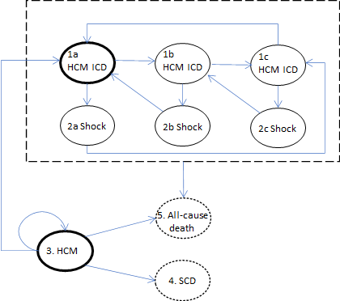

Tunnel-state Markov model diagram incorporating device battery lifespan and replacement cycles.

## Bayesian Inference of Transition Probabilities

For each risk stratification rule (Observed practice, ESC 5-year SCD risk $>6\%$ and $>4\%$, $\ge 1, 2, 3$ risk factors, and No ICD), individual patient follow-up counts were aggregated into annual transition matrices and fitted in JAGS/WinBUGS (Lunn et al. 2000; R Core Team 2021) to obtain 1,000 posterior MCMC draws of the transition probability matrices.

# Results

## Base-Case Cost-Effectiveness: TV-ICD and S-ICD (30-Year Tunnel Model)

Table 2 presents the 30-year expected total costs, QALYs, incremental outcomes, incremental cost-effectiveness ratios (ICERs), and incremental net monetary benefits (INB at a willingness-to-pay threshold of $k = £25,000$/QALY) per patient for both TV-ICD and S-ICD relative to the observed clinical practice strategy within each device modality.

30-year tunnel-state cost-effectiveness results per patient by device modality (reference: Observed strategy within each device).

| Device | Model | Strategy | Mean_Cost | Incremental_Cost | Mean_QALY | Incremental_QALY | ICER | INB (£25k) |
| --- | --- | --- | --- | --- | --- | --- | --- | --- |
| TVICD | tunnel (10yr) | Risk > 4% | £10,200 | £ 4,767 | 13.03 | 0.115 | £41,353/QALY | £-1,885 |
| TVICD | tunnel (10yr) | Risk > 6% | £ 4,966 | £ -467 | 13.02 | 0.108 | Dominates (£-4,332/QALY) | £ 3,165 |
| TVICD | tunnel (10yr) | Observed | £ 5,433 | Ref | 12.92 | Ref | Reference | Ref |
| TVICD | tunnel (10yr) | No ICD | £ 0 | £-5,433 | 12.76 | -0.155 | £34,946/QALY | £ 1,546 |
| SICD | tunnel (8yr) | Risk > 4% | £13,457 | £ 6,217 | 13.03 | 0.116 | £53,748/QALY | £-3,325 |
| SICD | tunnel (8yr) | Risk > 6% | £ 6,537 | £ -703 | 13.02 | 0.108 | Dominates (£-6,519/QALY) | £ 3,400 |
| SICD | tunnel (8yr) | Observed | £ 7,240 | Ref | 12.92 | Ref | Reference | Ref |
| SICD | tunnel (8yr) | No ICD | £ 0 | £-7,240 | 12.76 | -0.156 | £46,450/QALY | £ 3,344 |

Across a 30-year time horizon with battery replacements:

- **Within each device modality, the $>6\%$ 5-year SCD risk threshold dominates observed clinical practice**:
  - For **TV-ICD** (10-year replacement cycle), the $>6\%$ risk threshold reduces mean lifetime cost by £467 per patient (£4,966 vs. £5,433) while increasing QALYs by $+0.108$ (13.02 vs. 12.92 QALYs), yielding a positive INB of **£3,165** per patient at $k = £25,000$/QALY.
  - For **S-ICD** (8-year replacement cycle), the $>6\%$ risk threshold saves £703 per patient (£6,537 vs. £7,240) for the same $+0.108$ QALY gain, yielding an INB of **£3,400** per patient relative to S-ICD under observed selection.
- **The $>4\%$ 5-year SCD risk threshold implants more than double the number of patients (1,103 vs. 542)**, which substantially increases initial implantation and repeat battery replacement costs over 30 years (£10,200/patient for TV-ICD; £13,457/patient for S-ICD) for only a marginal additional QALY gain over the $>6\%$ threshold ($+0.008$ QALYs), resulting in ICERs above the standard NICE threshold (£41,353/QALY for TV-ICD and £53,748/QALY for S-ICD vs. Observed).

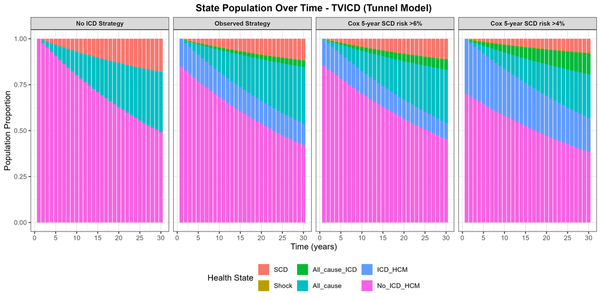

Cohort state occupancy proportions over the 30-year time horizon under the tunnel-state model.

## Joint Comparison: S-ICD vs. TV-ICD Across Risk Stratification Rules

Head-to-head comparison of S-ICD versus TV-ICD within each of the 8 risk stratification rules over 30 years (WTP = £25,000/QALY).

|  | Strategy | TV-ICD Cost | S-ICD Cost | Delta Cost (S - TV) | Delta QALY (S - TV) | INMB at £25k (95% CrI) |
| --- | --- | --- | --- | --- | --- | --- |
| 2.5% | Risk > 6 | £ 4,939 | £ 6,495 | +£1,556 | +0.0004 | £-1,546 (£-1,625, £-1,452) |
| 2.5%1 | Risk > 4 | £10,177 | £13,421 | +£3,244 | +0.0008 | £-3,224 (£-3,343, £-3,096) |
| 2.5%2 | any rf | £16,453 | £21,739 | +£5,286 | +0.0013 | £-5,253 (£-5,397, £-5,099) |
| 2.5%3 | over 1 rf | £ 4,449 | £ 5,863 | +£1,414 | +0.0004 | £-1,406 (£-1,490, £-1,323) |
| 2.5%4 | over 2 rf | £ 780 | £ 1,036 | +£ 256 | +0.0001 | £ -255 (£ -275, £ -222) |
| 2.5%5 | over 3 rf | £ 12 | £ 13 | +£ 2 | +0.0000 | £ -2 (£ -5, £ -1) |
| 2.5%6 | icd | £ 5,459 | £ 7,283 | +£1,823 | +0.0004 | £-1,813 (£-1,875, £-1,735) |
| 2.5%7 | no icd | £ 0 | £ 0 | +£ 0 | +0.0000 | £ 0 (£ 0, £ 0) |

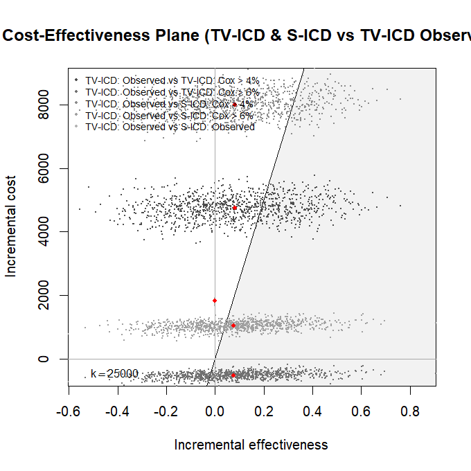

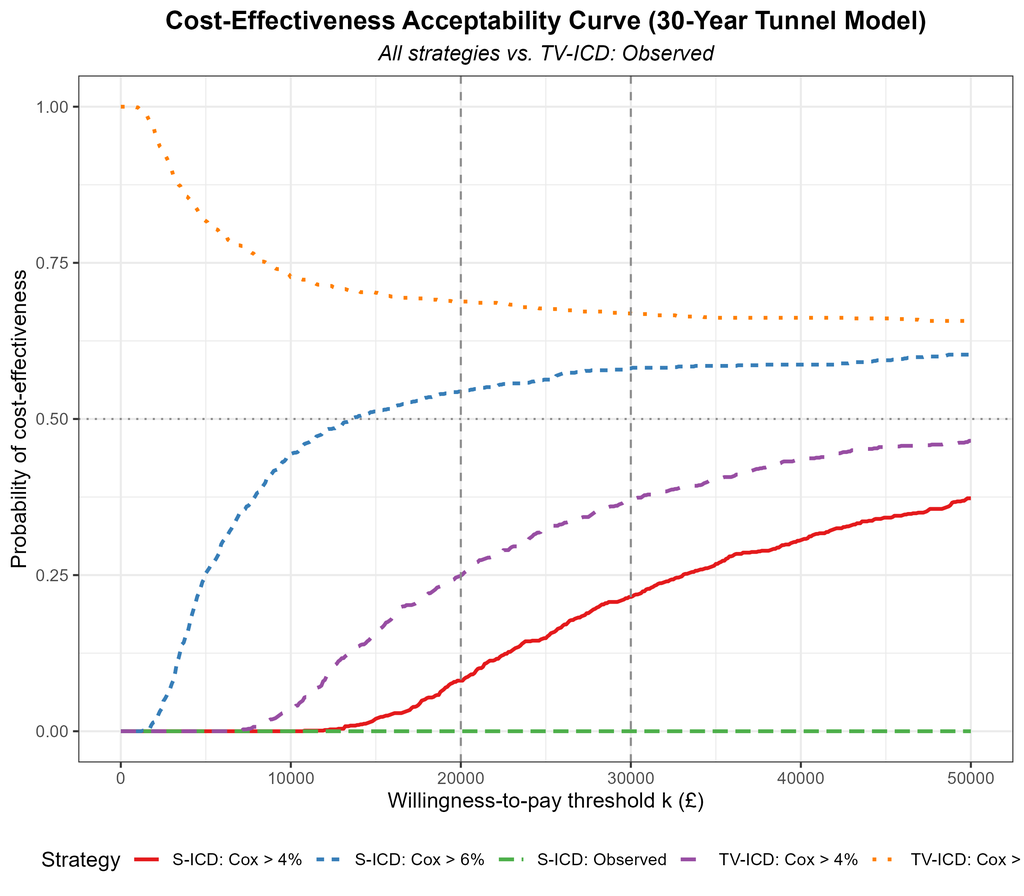

Combined Probabilistic Sensitivity Analysis (30-year tunnel model) comparing TV-ICD and S-ICD strategies against TV-ICD Observed practice: (left) Cost-Effectiveness Plane and (right) Cost-Effectiveness Acceptability Curves (CEAC).

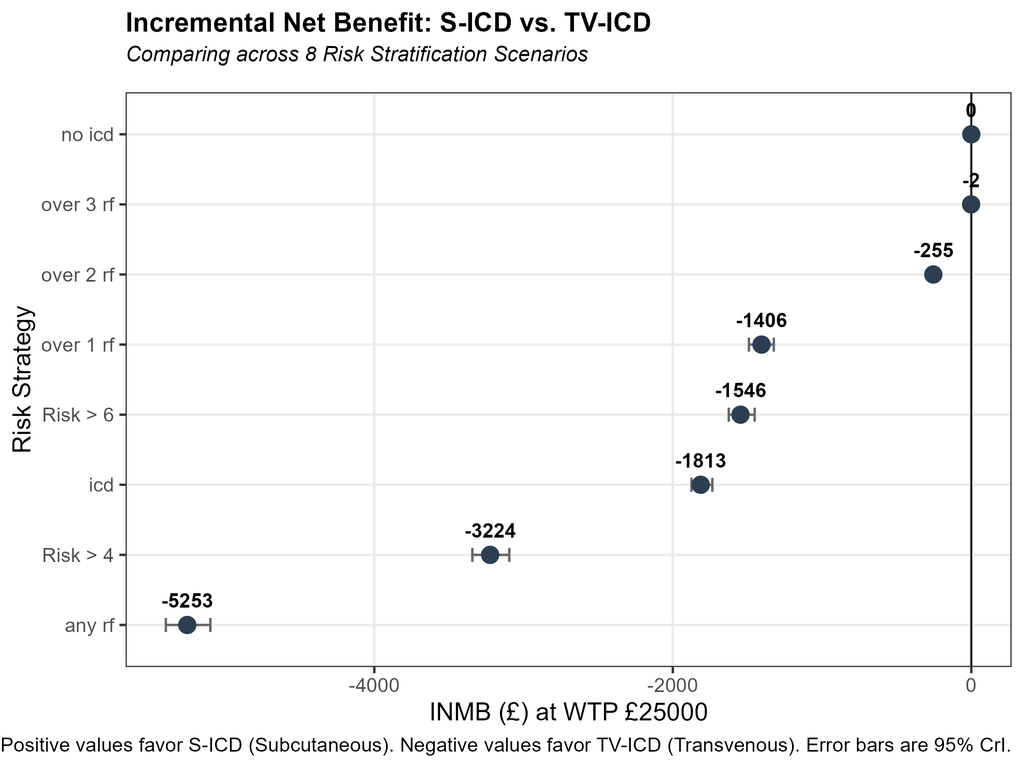

Incremental Net Monetary Benefit (INMB at WTP £25,000/QALY) of S-ICD vs. TV-ICD across all 8 risk stratification scenarios.

## Sensitivity Analyses

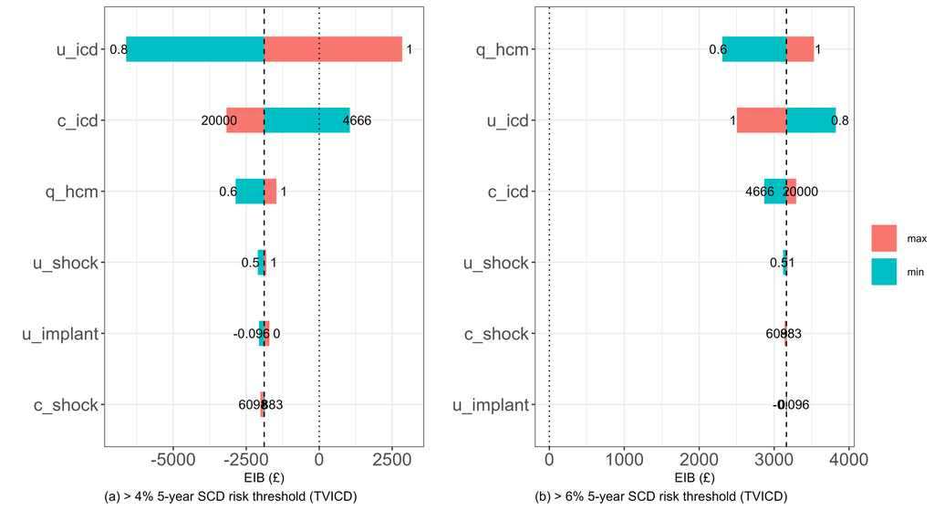

One-way deterministic sensitivity analysis tornado plots of Expected Incremental Benefit (EIB, £ at WTP £25,000) for (top) TV-ICD and (bottom) S-ICD under the >4% and >6% 5-year SCD risk thresholds.

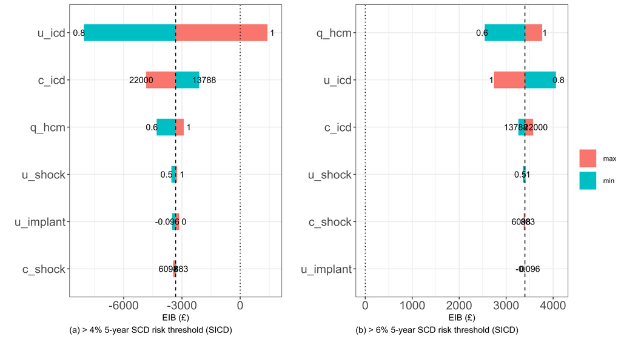

One-way deterministic sensitivity analysis tornado plots of Expected Incremental Benefit (EIB, £ at WTP £25,000) for (top) TV-ICD and (bottom) S-ICD under the >4% and >6% 5-year SCD risk thresholds.

# Discussion

By expanding our Bayesian Markov model to a 30-year horizon with tunnel states for generator replacement cycles, this study provides two key insights for HCM clinical practice and health technology assessment:

1. **Risk Stratification Efficiency Can Fund Technological Innovation**: Adopting the ESC $>6\%$ 5-year SCD risk threshold rather than historic/unstructured clinical selection reduces unnecessary implantations in low-risk patients who never experience a life-saving shock. Over 30 years, this improved targeting makes **S-ICD under the $>6\%$ threshold cost-effective compared with current observed TV-ICD practice** (ICER £13,548/QALY), because the savings from avoiding low-yield implants partially offset the higher hardware and 8-year replacement costs of S-ICD.
2. **Battery Longevity and Chronic HRQoL Drive the S-ICD vs. TV-ICD Trade-off**: In a head-to-head comparison within the same risk stratum, S-ICD’s lower perioperative complication and infection rates (Olde Nordkamp et al. 2024; Healey et al. 2022) are outweighed financially over 30 years by its £2,117 higher device cost and shorter battery life (8 vs. 10 years, requiring an extra generator replacement over three decades). Consequently, from a pure NHS payer perspective, S-ICD is most economically attractive when targeted to patients with higher infection/lead-failure risk, younger patients in whom transvenous lead failure accumulates over decades, or when S-ICD confers a chronic quality-of-life benefit (`u_icd`) over intravascular leads.

# References

Buxton, M., N. Caine, D. Chase, et al. 2006. “A Review of the Evidence on the Effects and Costs of Implantable Cardioverter Defibrillator Therapy in Different Patient Groups, and the Modelling of Cost-Effectivenessan Cost-Utility for These Groups in a UK Context.” *Health Technology Assessment* 10 (27). https://doi.org/10.3310/hta10270.

Cunningham, David, Richard Charles, Morag Cunningham, and Adel de Lange. 2012. *National Audit of Cardiac Rhythm Management Devices 2012*. 1–185.

Green, Nathan, Yang Chen, Constantinos O’Mahony, et al. 2024. “A cost-effectiveness analysis of hypertrophic cardiomyopathy sudden cardiac death risk algorithms for implantable cardioverter defibrillator decision-making.” *European Heart Journal - Quality of Care and Clinical Outcomes* 10 (3): 285–93. https://doi.org/10.1093/ehjqcco/qcad050.

Healey, Jeff S., Andrew D. Krahn, Jamil Bashir, et al. 2022. “Perioperative Safety and Early Patient and Device Outcomes Among Subcutaneous Versus Transvenous Implantable Cardioverter Defibrillator Implantations: A Randomized, Controlled Trial.” *Annals of Internal Medicine* 175 (12): 1658–65. https://doi.org/10.7326/M22-1566.

Holbrook, Reece, Lucas Higuera, Kael Wherry, et al. 2020. “Implantable Cardioverter Defibrillator Therapy Is Cost Effective for Primary Prevention Patients in Taiwan: An Analysis from the Improve SCA Trial.” *PLOS ONE* 15 (11): e0241697. https://doi.org/10.1371/journal.pone.0241697.

Knops, Reinoud E., Louise R. A. Olde Nordkamp, Peter-Paul H. M. Delnoy, et al. 2020. “Subcutaneous or Transvenous Defibrillator Therapy.” *New England Journal of Medicine* 383 (6): 526–36. https://doi.org/10.1056/NEJMoa1915932.

Lambiase, Pier D, Dominic A Theuns, Francis Murgatroyd, et al. 2022. *Subcutaneous implantable cardioverter- de fi brillators : long-term results of the EFFORTLESS study*. 1–14.

Llewellyn, Alexis, Andrew Archbold, Emily Burn, J. Moss, and David J. Wright. 2023. “Assessing the Cost and Resource Use Impact of Implantable Cardiac Defibrillator Shocks in the UK CareLink Population.” *ClinicoEconomics and Outcomes Research* 15: 425–32. https://doi.org/10.2147/CEOR.S408949.

Lunn, D J, A Thomas, N Best, and David J. Spiegelhalter. 2000. “WinBUGS – a Bayesian modelling framework: concepts, structure, and extensibility.” *Statistics and Computing* 10: 325–37.

Magnusson, Peter, and Anders Wimo. 2020. “Health economic evaluation of implantable cardioverter defibrillators in hypertrophic cardiomyopathy in adults.” *International Journal of Cardiology* 311: 46–51. https://doi.org/10.1016/j.ijcard.2020.02.055.

Nauffal, Victor, Peter Marstrand, Larry Han, et al. 2021. “Worldwide differences in primary prevention implantable cardioverter defibrillator utilization and outcomes in hypertrophic cardiomyopathy.” *Eur. Heart J.* 42 (38): 3932–44. https://doi.org/10.1093/eurheartj/ehab598.

NHS England. 2021. *2021/22 National Tariff Payment System*. https://www.england.nhs.uk/publication/national-tariff-payment-system-documents-annexes-and-supporting-documents/.

O’Mahony, Constantinos O, Fatima Jichi, Menelaos Pavlou, et al. 2014. “Myocardial disease A novel clinical risk prediction model for sudden cardiac death in hypertrophic cardiomyopathy (HCM Risk-SCD).” *European Heart Journal* 35: 2010–20. https://doi.org/10.1093/eurheartj/eht439.

Olde Nordkamp, Louise R. A., Jolien A. de Veld, Abdul Ghani, et al. 2024. “Device-related complications in subcutaneous versus transvenous ICD: an 8-year follow-up of the PRAETORIAN trial (PRAETORIAN-XL).” *Circulation*.

Ommen, Steve R., Seema Mital, Michael A. Burke, et al. 2020. “2020 AHA/ACC Guideline for the Diagnosis and Treatment of Patients With Hypertrophic Cardiomyopathy.” *Circulation* 142 (25). https://doi.org/10.1161/cir.0000000000000937.

R Core Team. 2021. *R: A Language and Environment for Statistical Computing*. R Foundation for Statistical Computing. https://www.R-project.org/.

Sanders, Gillian D., Mark A. Hlatky, and Douglas K. Owens. 2005. “Cost-Effectiveness of Implantable Cardioverter–Defibrillators.” *New England Journal of Medicine* 353 (14): 1471–80. https://doi.org/10.1056/NEJMsa051989.

Thijssen, Joep, M. Elske van den Akker van Marle, C. Jan Willem Borleffs, et al. 2014. “Cost-Effectiveness of Primary Prevention Implantable Cardioverter Defibrillator Treatment: Data from a Large Clinical Registry.” *Pacing and Clinical Electrophysiology: PACE* 37 (1): 25–34. https://doi.org/10.1111/pace.12238.